# Part I - Airline On-Time Performance Data for Summer 2022

```python
#Merge the 2 datraframe together to get a master datagframe
master_airline = pd.merge(carrier_cancelled, carrier_delayed).rename(columns={'CANCELLED_PERC': 'CANCELLED', 'DELAY_PERC': 'DELAYED'})
master_airline
```

|  | CARRIER_DESCRIPTION | CANCELLED | DELAYED |
| --- | --- | --- | --- |
| 0 | Alaska Airlines Inc. | 0.73 | 38.13 |
| 1 | Allegiant Air | 2.44 | 54.91 |
| 2 | American Airlines Inc. | 3.91 | 43.08 |
| 3 | Delta Air Lines Inc. | 1.64 | 29.90 |
| 4 | Endeavor Air Inc. | 4.82 | 28.12 |
| 5 | Envoy Air | 1.23 | 33.56 |
| 6 | Frontier Airlines Inc. | 1.86 | 43.81 |
| 7 | Hawaiian Airlines Inc. | 0.13 | 53.35 |
| 8 | Horizon Air | 0.35 | 35.47 |
| 9 | JetBlue Airways | 2.80 | 46.55 |
| 10 | Mesa Airlines Inc. | 2.41 | 34.27 |
| 11 | PSA Airlines Inc. | 2.97 | 36.39 |
| 12 | Republic Airline | 5.53 | 32.77 |
| 13 | SkyWest Airlines Inc. | 0.79 | 29.97 |
| 14 | Southwest Airlines Co. | 1.80 | 46.67 |
| 15 | Spirit Air Lines | 1.53 | 34.25 |
| 16 | United Air Lines Inc. | 2.02 | 32.63 |

```python
#Use melt to transform the dataframe, with one observation per row
melt_airlines = master_airline.melt(id_vars='CARRIER_DESCRIPTION',\
                               value_vars =['CANCELLED', 'DELAYED'], var_name='TYPE', value_name='PERCENTAGE')
melt_airlines
```

|  | CARRIER_DESCRIPTION | TYPE | PERCENTAGE |
| --- | --- | --- | --- |
| 0 | Alaska Airlines Inc. | CANCELLED | 0.73 |
| 1 | Allegiant Air | CANCELLED | 2.44 |
| 2 | American Airlines Inc. | CANCELLED | 3.91 |
| 3 | Delta Air Lines Inc. | CANCELLED | 1.64 |
| 4 | Endeavor Air Inc. | CANCELLED | 4.82 |
| 5 | Envoy Air | CANCELLED | 1.23 |
| 6 | Frontier Airlines Inc. | CANCELLED | 1.86 |
| 7 | Hawaiian Airlines Inc. | CANCELLED | 0.13 |
| 8 | Horizon Air | CANCELLED | 0.35 |
| 9 | JetBlue Airways | CANCELLED | 2.80 |
| 10 | Mesa Airlines Inc. | CANCELLED | 2.41 |
| 11 | PSA Airlines Inc. | CANCELLED | 2.97 |
| 12 | Republic Airline | CANCELLED | 5.53 |
| 13 | SkyWest Airlines Inc. | CANCELLED | 0.79 |
| 14 | Southwest Airlines Co. | CANCELLED | 1.80 |
| 15 | Spirit Air Lines | CANCELLED | 1.53 |
| 16 | United Air Lines Inc. | CANCELLED | 2.02 |
| 17 | Alaska Airlines Inc. | DELAYED | 38.13 |
| 18 | Allegiant Air | DELAYED | 54.91 |
| 19 | American Airlines Inc. | DELAYED | 43.08 |
| 20 | Delta Air Lines Inc. | DELAYED | 29.90 |
| 21 | Endeavor Air Inc. | DELAYED | 28.12 |
| 22 | Envoy Air | DELAYED | 33.56 |
| 23 | Frontier Airlines Inc. | DELAYED | 43.81 |
| 24 | Hawaiian Airlines Inc. | DELAYED | 53.35 |
| 25 | Horizon Air | DELAYED | 35.47 |
| 26 | JetBlue Airways | DELAYED | 46.55 |
| 27 | Mesa Airlines Inc. | DELAYED | 34.27 |
| 28 | PSA Airlines Inc. | DELAYED | 36.39 |
| 29 | Republic Airline | DELAYED | 32.77 |
| 30 | SkyWest Airlines Inc. | DELAYED | 29.97 |
| 31 | Southwest Airlines Co. | DELAYED | 46.67 |
| 32 | Spirit Air Lines | DELAYED | 34.25 |
| 33 | United Air Lines Inc. | DELAYED | 32.63 |

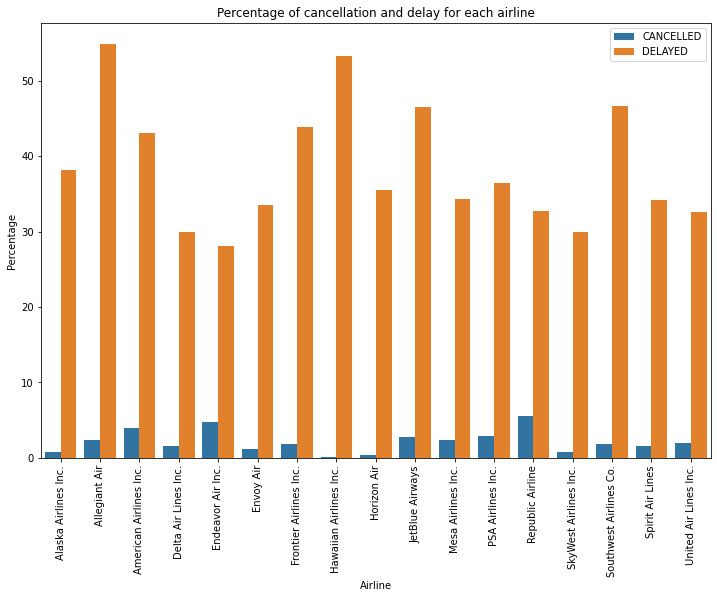

```python
#Create a bar plot with the percentage of cancelled and delayed flights for airline
plt.figure(figsize=(12,8))
sns.barplot(data=melt_airlines, x='CARRIER_DESCRIPTION', y='PERCENTAGE', hue='TYPE')
plt.xticks(rotation=90)
plt.legend(title='')
plt.ylabel('Percentage')
plt.xlabel('Airline')
plt.title('Percentage of cancellation and delay for each airline');
```

This plot gives us an overview of how well each airline performs cancellation and delay-wise. Hawaiian Airlines is doing great on cancellations, but over 50% of their flights were delayed. Even though Republic Airlines and Endeavor fare the worst regarding cancellation with 5%, their delay percentage is only about 30%. Our univariate visualization showed that a majority of the flights belonged to Southwest, Delta, and American Airlines. Looking at the three airlines in this graph, Delta is doing the best in both cancellations and delays. Southwest is doing better with cancellations than America, but America is doing better with delays.

Although this is interesting, using a multivariate plot for the cancellation and the delays does not give us any more insight into performance than if we had two separate graphs, one for cancellation and one for delays.

Has the location affected how well the airline is performing? Is there a state where the airline is doing better or worse than others? We can find out by comparing the cancellation and delay rates for each airline and each state. We will use a heatmap since we are working with two categorical variables.

Get the number of canceled flights per airline and state using Groupby.

```python
#Use groupby to group the airline per state, getting the number of cancellation for each.
state_carrier_cancel = flight_copy.groupby(['ORIGIN_STATE_ABR', 'CARRIER_DESCRIPTION'])['CANCELLATION_CODE'].count()
```

```python
#Create a dataframe using reset_index and rename columns for clarity
state_carrier_cancel = state_carrier_cancel.reset_index().rename(columns={'CANCELLATION_CODE':'CANCELLATION'})
state_carrier_cancel
```

|  | ORIGIN_STATE_ABR | CARRIER_DESCRIPTION | CANCELLATION |
| --- | --- | --- | --- |
| 0 | AK | Alaska Airlines Inc. | 187 |
| 1 | AK | American Airlines Inc. | 4 |
| 2 | AK | Delta Air Lines Inc. | 12 |
| 3 | AK | Horizon Air | 13 |
| 4 | AK | SkyWest Airlines Inc. | 3 |
| ... | ... | ... | ... |
| 617 | WY | Alaska Airlines Inc. | 0 |
| 618 | WY | American Airlines Inc. | 2 |
| 619 | WY | Delta Air Lines Inc. | 0 |
| 620 | WY | SkyWest Airlines Inc. | 34 |
| 621 | WY | United Air Lines Inc. | 6 |

622 rows × 3 columns

Get the total number of flights per airline and state of origin using groupby.

```python
#Use groupby
state_carrier = flight_copy.groupby(['ORIGIN_STATE_ABR', 'CARRIER_DESCRIPTION'])['YEAR'].count()
```

```python
#Create a new dataframe using reset index and rename columns for clarity
state_carrier = state_carrier.reset_index().rename(columns={'YEAR':'FLIGHT_COUNT'})
state_carrier
```

|  | ORIGIN_STATE_ABR | CARRIER_DESCRIPTION | FLIGHT_COUNT |
| --- | --- | --- | --- |
| 0 | AK | Alaska Airlines Inc. | 12892 |
| 1 | AK | American Airlines Inc. | 313 |
| 2 | AK | Delta Air Lines Inc. | 1652 |
| 3 | AK | Horizon Air | 1206 |
| 4 | AK | SkyWest Airlines Inc. | 183 |
| ... | ... | ... | ... |
| 617 | WY | Alaska Airlines Inc. | 48 |
| 618 | WY | American Airlines Inc. | 287 |
| 619 | WY | Delta Air Lines Inc. | 382 |
| 620 | WY | SkyWest Airlines Inc. | 2511 |
| 621 | WY | United Air Lines Inc. | 539 |

622 rows × 3 columns

Merge the two dataframes together.

```python
#Use merge
state_carrier_cancel = state_carrier_cancel.merge(state_carrier)
state_carrier_cancel
```

|  | ORIGIN_STATE_ABR | CARRIER_DESCRIPTION | CANCELLATION | FLIGHT_COUNT |
| --- | --- | --- | --- | --- |
| 0 | AK | Alaska Airlines Inc. | 187 | 12892 |
| 1 | AK | American Airlines Inc. | 4 | 313 |
| 2 | AK | Delta Air Lines Inc. | 12 | 1652 |
| 3 | AK | Horizon Air | 13 | 1206 |
| 4 | AK | SkyWest Airlines Inc. | 3 | 183 |
| ... | ... | ... | ... | ... |
| 617 | WY | Alaska Airlines Inc. | 0 | 48 |
| 618 | WY | American Airlines Inc. | 2 | 287 |
| 619 | WY | Delta Air Lines Inc. | 0 | 382 |
| 620 | WY | SkyWest Airlines Inc. | 34 | 2511 |
| 621 | WY | United Air Lines Inc. | 6 | 539 |

622 rows × 4 columns

Get the percentage of canceled flights by dividing the number of canceled flights by the total flights multiplied by 100 and rounding to 2 decimals.

```python
#Do the calculation using the cancellation  and the flight count columns
state_carrier_cancel['PERCENTAGE_CANCELLATION'] = round((state_carrier_cancel['CANCELLATION']\
                                                         / state_carrier_cancel['FLIGHT_COUNT'])* 100, 2)
```

```python
#Print the resulting state_carrier_cancel dataframe
state_carrier_cancel
```

|  | ORIGIN_STATE_ABR | CARRIER_DESCRIPTION | CANCELLATION | FLIGHT_COUNT | PERCENTAGE_CANCELLATION |
| --- | --- | --- | --- | --- | --- |
| 0 | AK | Alaska Airlines Inc. | 187 | 12892 | 1.45 |
| 1 | AK | American Airlines Inc. | 4 | 313 | 1.28 |
| 2 | AK | Delta Air Lines Inc. | 12 | 1652 | 0.73 |
| 3 | AK | Horizon Air | 13 | 1206 | 1.08 |
| 4 | AK | SkyWest Airlines Inc. | 3 | 183 | 1.64 |
| ... | ... | ... | ... | ... | ... |
| 617 | WY | Alaska Airlines Inc. | 0 | 48 | 0.00 |
| 618 | WY | American Airlines Inc. | 2 | 287 | 0.70 |
| 619 | WY | Delta Air Lines Inc. | 0 | 382 | 0.00 |
| 620 | WY | SkyWest Airlines Inc. | 34 | 2511 | 1.35 |
| 621 | WY | United Air Lines Inc. | 6 | 539 | 1.11 |

622 rows × 5 columns

This dataframe is relatively large with 622 rows. Visualizing this many data points is probably going to be difficult. Let's try it anyway.

Pivot the dataframe to have the carrier description as columns, the state as rows and the percentage as values.

```python
#Pivot the dataframe using pivot and save it under ab new dataframe
state_carrier_cancel_pivot = state_carrier_cancel.pivot(index = 'ORIGIN_STATE_ABR', columns = 'CARRIER_DESCRIPTION', values = 'PERCENTAGE_CANCELLATION')
state_carrier_cancel_pivot
```

| CARRIER_DESCRIPTION ORIGIN_STATE_ABR | Alaska Airlines Inc. | Allegiant Air | American Airlines Inc. | Delta Air Lines Inc. | Endeavor Air Inc. | Envoy Air | Frontier Airlines Inc. | Hawaiian Airlines Inc. | Horizon Air | JetBlue Airways | Mesa Airlines Inc. | PSA Airlines Inc. | Republic Airline | SkyWest Airlines Inc. | Southwest Airlines Co. | Spirit Air Lines | United Air Lines Inc. |
| --- | --- | --- | --- | --- | --- | --- | --- | --- | --- | --- | --- | --- | --- | --- | --- | --- | --- |
| AK | 1.45 | NaN | 1.28 | 0.73 | NaN | NaN | NaN | NaN | 1.08 | NaN | NaN | NaN | NaN | 1.64 | NaN | NaN | 0.74 |
| AL | NaN | NaN | 3.72 | 1.41 | 1.43 | 0.96 | 0.00 | NaN | NaN | NaN | 4.41 | 3.98 | 0.00 | 1.65 | 1.98 | NaN | 0.00 |
| AR | NaN | 3.14 | 3.70 | 0.97 | 0.91 | 0.60 | 2.07 | NaN | NaN | NaN | 1.09 | 1.91 | 4.04 | 1.59 | 1.12 | NaN | 0.00 |
| AZ | 0.15 | 0.84 | 2.39 | 1.42 | NaN | NaN | 1.54 | 0.00 | 0.71 | 2.40 | 2.04 | NaN | NaN | 0.25 | 1.30 | 0.93 | 1.26 |
| CA | 0.55 | 2.57 | 2.95 | 1.47 | NaN | 0.00 | 1.16 | 0.46 | 0.42 | 0.67 | 2.76 | NaN | NaN | 0.45 | 1.51 | 0.99 | 1.10 |
| CO | 0.28 | 2.37 | 2.80 | 1.64 | NaN | 0.23 | 0.67 | NaN | NaN | 1.94 | 5.36 | NaN | NaN | 1.13 | 1.66 | 0.41 | 1.39 |
| CT | NaN | NaN | 3.74 | 1.34 | 5.19 | 0.00 | 1.64 | NaN | NaN | 1.49 | 2.75 | 3.80 | 2.81 | 0.00 | 2.56 | 1.67 | 2.01 |
| DE | NaN | NaN | NaN | NaN | NaN | NaN | 0.00 | NaN | NaN | NaN | NaN | NaN | NaN | NaN | NaN | NaN | NaN |
| FL | 2.57 | 2.98 | 4.65 | 2.72 | 6.45 | 1.95 | 3.09 | 0.00 | NaN | 3.70 | 3.47 | 3.41 | 4.55 | 2.08 | 3.03 | 2.08 | 4.17 |
| GA | 0.95 | 3.53 | 3.71 | 1.37 | 1.13 | 1.52 | 1.97 | NaN | NaN | 4.21 | 1.57 | 2.10 | 4.91 | 1.50 | 1.66 | 0.69 | 2.88 |
| HI | 0.87 | NaN | 0.33 | 0.94 | NaN | NaN | NaN | 0.08 | NaN | NaN | NaN | NaN | NaN | NaN | 0.47 | NaN | 0.54 |
| IA | NaN | 1.16 | 4.52 | 0.21 | 0.75 | 1.35 | 0.00 | NaN | NaN | NaN | 2.20 | 1.12 | 1.71 | 1.46 | 0.41 | NaN | 1.23 |
| ID | 0.30 | 2.09 | 4.44 | 1.15 | NaN | 0.85 | NaN | NaN | 0.37 | NaN | 0.00 | NaN | NaN | 0.44 | 0.26 | 3.51 | 1.34 |
| IL | 0.37 | 2.33 | 4.32 | 1.84 | 5.58 | 1.25 | 1.94 | NaN | 0.00 | 4.10 | 2.50 | 0.82 | 2.11 | 1.93 | 2.26 | 1.12 | 1.89 |
| IN | 0.99 | 2.79 | 3.94 | 0.68 | 4.61 | 1.14 | 1.70 | NaN | NaN | NaN | 0.00 | 1.25 | 3.74 | 1.19 | 1.46 | 1.61 | 1.34 |
| KS | NaN | 0.50 | 5.94 | 0.28 | NaN | 1.00 | NaN | NaN | 0.86 | NaN | 3.03 | NaN | 0.00 | 0.71 | 0.00 | NaN | 0.67 |
| KY | 0.00 | 3.43 | 3.88 | 1.48 | 3.98 | 1.39 | 1.91 | NaN | NaN | NaN | 1.93 | 2.57 | 4.73 | 1.25 | 1.92 | 1.66 | 1.51 |
| LA | 0.00 | 0.00 | 4.00 | 1.02 | 0.56 | 1.30 | 2.15 | NaN | NaN | 2.45 | 2.80 | 1.71 | 3.72 | 1.96 | 1.21 | 1.02 | 2.02 |
| MA | 0.73 | 2.28 | 3.97 | 1.81 | 5.68 | 2.29 | 4.03 | 0.00 | NaN | 2.21 | 0.00 | NaN | 3.02 | NaN | 1.44 | 1.71 | 2.48 |
| MD | 1.75 | 2.73 | 5.30 | 2.92 | 9.88 | 4.60 | 3.70 | NaN | NaN | 0.79 | NaN | 0.00 | 2.11 | 1.41 | 2.97 | 1.48 | 2.22 |
| ME | NaN | 1.87 | 3.67 | 0.88 | 7.95 | 0.81 | 3.08 | NaN | NaN | 4.61 | NaN | 4.17 | 8.61 | 0.00 | 2.35 | NaN | 1.35 |
| MI | 0.91 | 2.61 | 4.09 | 1.45 | 1.48 | 1.34 | 1.95 | NaN | NaN | 1.33 | 1.51 | 4.25 | 6.10 | 0.64 | 1.45 | 1.06 | 1.58 |
| MN | 0.51 | 0.00 | 3.12 | 0.96 | 1.04 | 2.21 | 1.23 | NaN | 0.00 | 3.89 | 2.69 | 4.13 | 5.83 | 0.17 | 1.68 | 1.10 | 1.84 |
| MO | 0.21 | 2.02 | 4.21 | 1.29 | 8.02 | 0.76 | 2.11 | NaN | NaN | 1.23 | 1.17 | 3.40 | 5.88 | 0.96 | 1.48 | 2.53 | 2.03 |
| MS | NaN | 0.00 | NaN | 0.49 | 0.70 | 0.00 | NaN | NaN | NaN | NaN | 4.30 | 2.24 | NaN | 1.43 | 0.86 | NaN | NaN |
| MT | 0.00 | 2.19 | 0.77 | 0.89 | NaN | 0.32 | 0.00 | NaN | 0.13 | 0.00 | 1.09 | NaN | NaN | 0.26 | 1.58 | NaN | 1.68 |
| NC | 0.00 | 3.37 | 3.89 | 1.15 | 6.72 | 1.15 | 2.23 | NaN | NaN | 3.26 | 1.86 | 2.42 | 4.57 | 2.95 | 2.03 | 1.81 | 3.00 |
| ND | NaN | 1.63 | NaN | 0.81 | NaN | 0.41 | 0.00 | NaN | NaN | NaN | 2.50 | NaN | NaN | 0.52 | NaN | NaN | NaN |
| NE | 0.82 | 3.20 | 3.99 | 1.56 | 7.53 | 0.60 | 2.38 | NaN | NaN | NaN | 0.00 | NaN | 5.05 | 1.17 | 1.32 | NaN | 1.71 |
| NH | NaN | 2.90 | 3.38 | NaN | NaN | 1.71 | NaN | NaN | NaN | NaN | NaN | 3.45 | 8.13 | 3.85 | 1.83 | 3.02 | NaN |
| NJ | 0.80 | 3.27 | 6.75 | 3.46 | 9.56 | NaN | 3.83 | NaN | NaN | 3.13 | NaN | NaN | 11.82 | 2.71 | NaN | 1.97 | 4.67 |
| NM | 0.46 | NaN | 2.06 | 0.98 | NaN | 1.61 | 2.86 | NaN | NaN | 0.82 | 2.67 | NaN | NaN | 0.48 | 0.72 | 1.69 | 1.37 |
| NV | 1.01 | 1.07 | 2.88 | 1.37 | NaN | 2.46 | 1.03 | 0.00 | 0.71 | 1.25 | 5.26 | NaN | NaN | 0.32 | 2.03 | 1.13 | 1.92 |
| NY | 0.41 | 2.67 | 5.98 | 3.41 | 7.30 | 1.60 | 2.55 | 0.00 | NaN | 3.19 | 4.45 | 3.27 | 5.99 | 1.61 | 3.40 | 2.52 | 3.20 |
| OH | 0.44 | 3.78 | 2.95 | 1.64 | 5.95 | 0.92 | 2.79 | NaN | NaN | 1.59 | 1.07 | 2.46 | 5.34 | 1.01 | 1.66 | 1.39 | 1.51 |
| OK | 0.00 | 1.06 | 3.09 | 0.20 | 0.00 | 1.09 | 3.57 | NaN | NaN | NaN | 1.46 | 3.62 | 4.13 | 0.67 | 1.20 | NaN | 1.00 |
| OR | 0.64 | 2.28 | 2.23 | 1.41 | NaN | NaN | 0.91 | 0.41 | 0.30 | 1.27 | 0.00 | NaN | NaN | 0.17 | 0.87 | 2.39 | 1.01 |
| PA | 0.47 | 2.78 | 3.66 | 1.73 | 6.49 | 2.63 | 1.96 | NaN | NaN | 1.48 | 2.26 | 2.49 | 3.98 | 1.49 | 2.08 | 1.69 | 1.46 |
| PR | NaN | NaN | 3.05 | 2.13 | NaN | NaN | 3.28 | NaN | NaN | 3.47 | NaN | NaN | NaN | NaN | 2.08 | 2.60 | 1.52 |
| RI | NaN | 2.20 | 6.57 | 1.36 | 5.87 | 2.82 | 2.26 | NaN | NaN | 2.65 | NaN | 3.80 | 8.18 | 0.00 | 2.47 | NaN | NaN |
| SC | 3.28 | 3.12 | 4.52 | 1.43 | 8.26 | 1.72 | 1.49 | NaN | NaN | 4.97 | 1.70 | 3.30 | 6.04 | 0.60 | 2.02 | 1.44 | 5.13 |
| SD | NaN | 1.49 | 0.79 | 1.65 | 0.00 | 1.49 | 0.98 | NaN | NaN | NaN | 2.76 | NaN | 1.92 | 0.56 | NaN | NaN | 1.07 |
| TN | 1.67 | 2.14 | 3.56 | 1.24 | 3.24 | 1.38 | 0.55 | NaN | NaN | 3.47 | 2.83 | 2.89 | 5.17 | 1.31 | 1.33 | 2.15 | 2.51 |
| TT | NaN | NaN | NaN | NaN | NaN | NaN | NaN | 0.00 | NaN | NaN | NaN | NaN | NaN | NaN | NaN | NaN | 0.00 |
| TX | 1.06 | 1.08 | 3.61 | 1.39 | 4.40 | 1.02 | 1.53 | 0.00 | 3.23 | 2.14 | 2.40 | NaN | 6.22 | 1.27 | 1.58 | 0.87 | 1.58 |
| UT | 0.47 | 1.26 | 4.04 | 1.28 | NaN | NaN | 0.77 | NaN | NaN | 0.90 | 2.05 | NaN | NaN | 0.12 | 1.15 | 1.02 | 2.53 |
| VA | 0.85 | 3.39 | 5.92 | 1.82 | 6.38 | 2.16 | 1.97 | NaN | NaN | 2.92 | 2.32 | 3.95 | 4.71 | 1.24 | 2.94 | 1.24 | 2.24 |
| VI | NaN | NaN | 2.30 | 2.68 | NaN | NaN | 0.00 | NaN | NaN | 3.70 | NaN | NaN | NaN | NaN | NaN | 2.62 | 2.90 |
| VT | NaN | NaN | 3.67 | 1.22 | 7.19 | 1.61 | 0.00 | NaN | NaN | 2.46 | 0.00 | 2.81 | 5.05 | 0.94 | NaN | NaN | 2.49 |
| WA | 0.43 | 0.93 | 2.20 | 1.74 | NaN | NaN | 1.47 | 0.41 | 0.28 | 0.80 | NaN | NaN | NaN | 0.13 | 0.67 | 0.75 | 0.94 |
| WI | 0.81 | 2.32 | 3.41 | 0.94 | 5.19 | 1.77 | 1.91 | NaN | NaN | 1.64 | 0.58 | 2.32 | 8.10 | 0.83 | 1.43 | 1.22 | 0.97 |
| WV | NaN | 3.68 | NaN | NaN | 0.00 | NaN | NaN | NaN | NaN | NaN | NaN | 3.63 | NaN | 1.25 | NaN | 1.92 | NaN |
| WY | 0.00 | NaN | 0.70 | 0.00 | NaN | NaN | NaN | NaN | NaN | NaN | NaN | NaN | NaN | 1.35 | NaN | NaN | 1.11 |

Using this dataframe, create a heatmap.

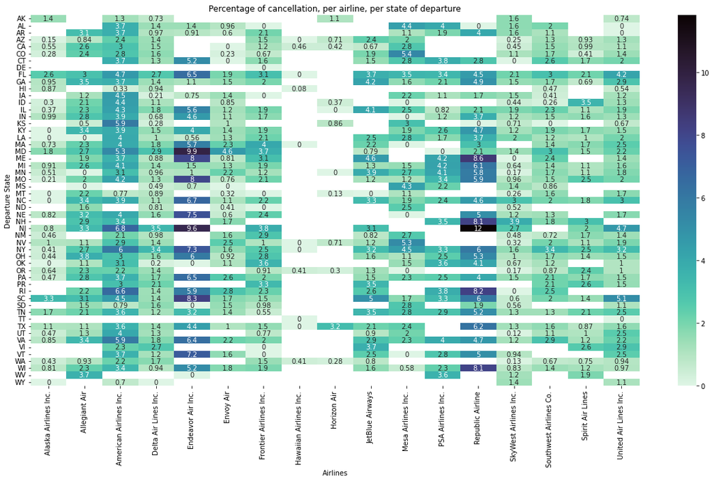

```python
#Heatmap
plt.figure(figsize=(20,10))
sns.heatmap(state_carrier_cancel_pivot, annot=True, cmap='mako_r')
plt.ylabel('Departure State')
plt.xlabel('Airlines')
plt.title('Percentage of cancellation, per airline, per state of departure');
```

As expected, too many data points make this visualization hard to read. However, the color palette is helpful to underline the area with a high percentage. The darker colors are mainly on the Endeavor Air, Republic Airline, and American Airlines columns.

To avoid such a busy visualization, let's focus on the top 5 states instead, a.k .a. the states with the most flights.

To find out which states have the highest flight traffic, we can use value_counts and only keep the first five rows using .head(5).

```python
#Get the top 5 state using value_counts()
flight_copy['ORIGIN_STATE_ABR'].value_counts().head(5)
```

```
CA    258713
TX    243258
FL    180117
NY    130921
IL    126130
Name: ORIGIN_STATE_ABR, dtype: int64
```

```python
#Save the top 5 state indexes in a list
top_5_state = list(flight_copy['ORIGIN_STATE_ABR'].value_counts().head(5).index)
top_5_state
```

```
['CA', 'TX', 'FL', 'NY', 'IL']
```

Create a dataframe with only the CA, FL, IL, NY and TX states from state_carrier_cancel_pivot using loc and top_5_state.

```python
#Create a new dataframe with only the top 5 state using loc
state_carrier_cancel_top5 = state_carrier_cancel_pivot.loc[top_5_state]
```

```python
#Print the new dataframe we just created
state_carrier_cancel_top5
```

| CARRIER_DESCRIPTION ORIGIN_STATE_ABR | Alaska Airlines Inc. | Allegiant Air | American Airlines Inc. | Delta Air Lines Inc. | Endeavor Air Inc. | Envoy Air | Frontier Airlines Inc. | Hawaiian Airlines Inc. | Horizon Air | JetBlue Airways | Mesa Airlines Inc. | PSA Airlines Inc. | Republic Airline | SkyWest Airlines Inc. | Southwest Airlines Co. | Spirit Air Lines | United Air Lines Inc. |
| --- | --- | --- | --- | --- | --- | --- | --- | --- | --- | --- | --- | --- | --- | --- | --- | --- | --- |
| CA | 0.55 | 2.57 | 2.95 | 1.47 | NaN | 0.00 | 1.16 | 0.46 | 0.42 | 0.67 | 2.76 | NaN | NaN | 0.45 | 1.51 | 0.99 | 1.10 |
| TX | 1.06 | 1.08 | 3.61 | 1.39 | 4.40 | 1.02 | 1.53 | 0.00 | 3.23 | 2.14 | 2.40 | NaN | 6.22 | 1.27 | 1.58 | 0.87 | 1.58 |
| FL | 2.57 | 2.98 | 4.65 | 2.72 | 6.45 | 1.95 | 3.09 | 0.00 | NaN | 3.70 | 3.47 | 3.41 | 4.55 | 2.08 | 3.03 | 2.08 | 4.17 |
| NY | 0.41 | 2.67 | 5.98 | 3.41 | 7.30 | 1.60 | 2.55 | 0.00 | NaN | 3.19 | 4.45 | 3.27 | 5.99 | 1.61 | 3.40 | 2.52 | 3.20 |
| IL | 0.37 | 2.33 | 4.32 | 1.84 | 5.58 | 1.25 | 1.94 | NaN | 0.00 | 4.10 | 2.50 | 0.82 | 2.11 | 1.93 | 2.26 | 1.12 | 1.89 |

Create a heatmap using this new dataframe.

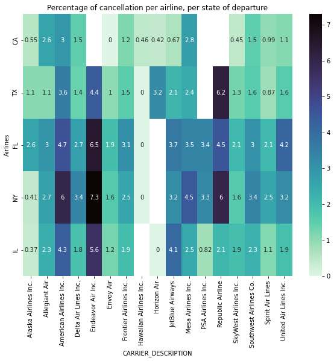

```python
#Display the heatmap
plt.figure(figsize=(10,8))
sns.heatmap(state_carrier_cancel_top5, annot=True, cmap='mako_r')
plt.ylabel('Departure State (top 5)')
plt.ylabel('Airlines')
plt.title('Percentage of cancellation per airline, per state of departure');
```

We also observe Endeavor Air, Republic Airline, and American Airlines having the highest cancellations percentage overall.

The cancellation percentage is high, specifically in Florida and New York. However, it is not tied to a specific airline; they all perform poorly.

Let's repeat the process with delays instead of cancellations.

```python
#Group by state and airline, and get the number of delayed flights for each.
state_carrier_delay = flight_copy.groupby(['ORIGIN_STATE_ABR', 'CARRIER_DESCRIPTION'])['ARR_DELAY_NEW'].count()
state_carrier_delay
```

```
ORIGIN_STATE_ABR  CARRIER_DESCRIPTION
AK                Alaska Airlines Inc.      4787
                  American Airlines Inc.     180
                  Delta Air Lines Inc.       396
                  Horizon Air                515
                  SkyWest Airlines Inc.       47
                                            ...
WY                Alaska Airlines Inc.        22
                  American Airlines Inc.     112
                  Delta Air Lines Inc.       119
                  SkyWest Airlines Inc.      730
                  United Air Lines Inc.      191
Name: ARR_DELAY_NEW, Length: 622, dtype: int64
```

```python
#Create a dataframe using reset_index() and rename columns
state_carrier_delay =  state_carrier_delay.reset_index().rename(columns={'ARR_DELAY_NEW':'DELAYED_FLIGHTS'})
state_carrier_delay
```

|  | ORIGIN_STATE_ABR | CARRIER_DESCRIPTION | DELAYED_FLIGHTS |
| --- | --- | --- | --- |
| 0 | AK | Alaska Airlines Inc. | 4787 |
| 1 | AK | American Airlines Inc. | 180 |
| 2 | AK | Delta Air Lines Inc. | 396 |
| 3 | AK | Horizon Air | 515 |
| 4 | AK | SkyWest Airlines Inc. | 47 |
| ... | ... | ... | ... |
| 617 | WY | Alaska Airlines Inc. | 22 |
| 618 | WY | American Airlines Inc. | 112 |
| 619 | WY | Delta Air Lines Inc. | 119 |
| 620 | WY | SkyWest Airlines Inc. | 730 |
| 621 | WY | United Air Lines Inc. | 191 |

622 rows × 3 columns

```python
#Get the total number of flights, per state, per airline
state_carrier_flight = flight_copy.groupby(['ORIGIN_STATE_ABR', 'CARRIER_DESCRIPTION'])['ARR_TIME'].count()
state_carrier_flight
```

```
ORIGIN_STATE_ABR  CARRIER_DESCRIPTION
AK                Alaska Airlines Inc.      12705
                  American Airlines Inc.      309
                  Delta Air Lines Inc.       1640
                  Horizon Air                1193
                  SkyWest Airlines Inc.       180
                                            ...
WY                Alaska Airlines Inc.         48
                  American Airlines Inc.      285
                  Delta Air Lines Inc.        382
                  SkyWest Airlines Inc.      2477
                  United Air Lines Inc.       533
Name: ARR_TIME, Length: 622, dtype: int64
```

```python
#Turn the serie in a dataframe using reset_index, et rename columns
state_carrier_flight = state_carrier_flight.reset_index().rename(columns={'ARR_TIME':'TOTAL_FLIGHT'})
state_carrier_flight
```

|  | ORIGIN_STATE_ABR | CARRIER_DESCRIPTION | TOTAL_FLIGHT |
| --- | --- | --- | --- |
| 0 | AK | Alaska Airlines Inc. | 12705 |
| 1 | AK | American Airlines Inc. | 309 |
| 2 | AK | Delta Air Lines Inc. | 1640 |
| 3 | AK | Horizon Air | 1193 |
| 4 | AK | SkyWest Airlines Inc. | 180 |
| ... | ... | ... | ... |
| 617 | WY | Alaska Airlines Inc. | 48 |
| 618 | WY | American Airlines Inc. | 285 |
| 619 | WY | Delta Air Lines Inc. | 382 |
| 620 | WY | SkyWest Airlines Inc. | 2477 |
| 621 | WY | United Air Lines Inc. | 533 |

622 rows × 3 columns

```python
#Merge the two dataframe together
state_carrier_merge = state_carrier_delay.merge(state_carrier_flight)
```

```python
#Print state_carrier_merge
state_carrier_merge
```

|  | ORIGIN_STATE_ABR | CARRIER_DESCRIPTION | DELAYED_FLIGHTS | TOTAL_FLIGHT |
| --- | --- | --- | --- | --- |
| 0 | AK | Alaska Airlines Inc. | 4787 | 12705 |
| 1 | AK | American Airlines Inc. | 180 | 309 |
| 2 | AK | Delta Air Lines Inc. | 396 | 1640 |
| 3 | AK | Horizon Air | 515 | 1193 |
| 4 | AK | SkyWest Airlines Inc. | 47 | 180 |
| ... | ... | ... | ... | ... |
| 617 | WY | Alaska Airlines Inc. | 22 | 48 |
| 618 | WY | American Airlines Inc. | 112 | 285 |
| 619 | WY | Delta Air Lines Inc. | 119 | 382 |
| 620 | WY | SkyWest Airlines Inc. | 730 | 2477 |
| 621 | WY | United Air Lines Inc. | 191 | 533 |

622 rows × 4 columns

```python
#Get the delay percentage
state_carrier_merge['PERCENTAGE_DELAY'] = np.round(state_carrier_merge['DELAYED_FLIGHTS'] \
                                                  / state_carrier_merge['TOTAL_FLIGHT'], 2)
```

```python
#print the dataframe
state_carrier_merge
```

|  | ORIGIN_STATE_ABR | CARRIER_DESCRIPTION | DELAYED_FLIGHTS | TOTAL_FLIGHT | PERCENTAGE_DELAY |
| --- | --- | --- | --- | --- | --- |
| 0 | AK | Alaska Airlines Inc. | 4787 | 12705 | 0.38 |
| 1 | AK | American Airlines Inc. | 180 | 309 | 0.58 |
| 2 | AK | Delta Air Lines Inc. | 396 | 1640 | 0.24 |
| 3 | AK | Horizon Air | 515 | 1193 | 0.43 |
| 4 | AK | SkyWest Airlines Inc. | 47 | 180 | 0.26 |
| ... | ... | ... | ... | ... | ... |
| 617 | WY | Alaska Airlines Inc. | 22 | 48 | 0.46 |
| 618 | WY | American Airlines Inc. | 112 | 285 | 0.39 |
| 619 | WY | Delta Air Lines Inc. | 119 | 382 | 0.31 |
| 620 | WY | SkyWest Airlines Inc. | 730 | 2477 | 0.29 |
| 621 | WY | United Air Lines Inc. | 191 | 533 | 0.36 |

622 rows × 5 columns

```python
#pivot the dataframe so each row is a state and each column an airline, the value being the delay percentage
state_carrier_delay_pivot = state_carrier_merge.pivot(index = 'ORIGIN_STATE_ABR', \
                                                      columns = 'CARRIER_DESCRIPTION', values = 'PERCENTAGE_DELAY')
state_carrier_delay_pivot
```

| CARRIER_DESCRIPTION ORIGIN_STATE_ABR | Alaska Airlines Inc. | Allegiant Air | American Airlines Inc. | Delta Air Lines Inc. | Endeavor Air Inc. | Envoy Air | Frontier Airlines Inc. | Hawaiian Airlines Inc. | Horizon Air | JetBlue Airways | Mesa Airlines Inc. | PSA Airlines Inc. | Republic Airline | SkyWest Airlines Inc. | Southwest Airlines Co. | Spirit Air Lines | United Air Lines Inc. |
| --- | --- | --- | --- | --- | --- | --- | --- | --- | --- | --- | --- | --- | --- | --- | --- | --- | --- |
| AK | 0.38 | NaN | 0.58 | 0.24 | NaN | NaN | NaN | NaN | 0.43 | NaN | NaN | NaN | NaN | 0.26 | NaN | NaN | 0.45 |
| AL | NaN | NaN | 0.54 | 0.21 | 0.31 | 0.36 | 0.39 | NaN | NaN | NaN | 0.41 | 0.38 | 0.50 | 0.41 | 0.45 | NaN | 0.33 |
| AR | NaN | 0.66 | 0.31 | 0.19 | 0.28 | 0.38 | 0.42 | NaN | NaN | NaN | 0.22 | 0.39 | 0.29 | 0.40 | 0.28 | NaN | 1.00 |
| AZ | 0.34 | 0.37 | 0.38 | 0.21 | NaN | NaN | 0.32 | 0.27 | 0.57 | 0.71 | 0.43 | NaN | NaN | 0.32 | 0.52 | 0.45 | 0.26 |
| CA | 0.35 | 0.63 | 0.40 | 0.30 | NaN | 0.55 | 0.44 | 0.32 | 0.38 | 0.43 | 0.39 | NaN | NaN | 0.30 | 0.46 | 0.40 | 0.30 |
| CO | 0.38 | 0.60 | 0.37 | 0.29 | NaN | 0.30 | 0.42 | NaN | NaN | 0.58 | 0.25 | NaN | NaN | 0.37 | 0.53 | 0.44 | 0.40 |
| CT | NaN | NaN | 0.41 | 0.25 | 0.45 | 0.00 | 0.49 | NaN | NaN | 0.48 | 0.26 | 0.34 | 0.27 | 0.35 | 0.42 | 0.31 | 0.24 |
| DE | NaN | NaN | NaN | NaN | NaN | NaN | 1.00 | NaN | NaN | NaN | NaN | NaN | NaN | NaN | NaN | NaN | NaN |
| FL | 0.40 | 0.51 | 0.44 | 0.31 | 0.31 | 0.34 | 0.48 | 0.60 | NaN | 0.49 | 0.40 | 0.34 | 0.40 | 0.36 | 0.46 | 0.35 | 0.36 |
| GA | 0.29 | 0.65 | 0.36 | 0.34 | 0.32 | 0.36 | 0.50 | NaN | NaN | 0.55 | 0.19 | 0.31 | 0.33 | 0.40 | 0.44 | 0.28 | 0.32 |
| HI | 0.36 | NaN | 0.23 | 0.21 | NaN | NaN | NaN | 0.56 | NaN | NaN | NaN | NaN | NaN | NaN | 0.38 | NaN | 0.23 |
| IA | NaN | 0.53 | 0.30 | 0.18 | 0.21 | 0.22 | 0.39 | NaN | NaN | NaN | 0.32 | 0.39 | 0.29 | 0.24 | 0.18 | NaN | 0.31 |
| ID | 0.37 | 0.72 | 0.39 | 0.26 | NaN | 0.22 | NaN | NaN | 0.28 | NaN | 0.67 | NaN | NaN | 0.24 | 0.37 | 0.58 | 0.24 |
| IL | 0.33 | 0.57 | 0.50 | 0.24 | 0.24 | 0.32 | 0.48 | NaN | 0.54 | 0.31 | 0.37 | 0.38 | 0.27 | 0.29 | 0.56 | 0.32 | 0.30 |
| IN | 0.34 | 0.54 | 0.38 | 0.26 | 0.33 | 0.31 | 0.45 | NaN | NaN | NaN | 0.38 | 0.24 | 0.32 | 0.29 | 0.45 | 0.39 | 0.34 |
| KS | NaN | 0.50 | 0.44 | 0.14 | NaN | 0.29 | NaN | NaN | 0.17 | NaN | 0.20 | NaN | 0.17 | 0.29 | 0.28 | NaN | 0.21 |
| KY | 0.30 | 0.58 | 0.43 | 0.22 | 0.25 | 0.34 | 0.39 | NaN | NaN | NaN | 0.37 | 0.38 | 0.29 | 0.25 | 0.38 | 0.22 | 0.22 |
| LA | 0.37 | 0.83 | 0.44 | 0.24 | 0.37 | 0.37 | 0.39 | NaN | NaN | 0.51 | 0.22 | 0.42 | 0.42 | 0.36 | 0.44 | 0.32 | 0.22 |
| MA | 0.36 | 0.65 | 0.33 | 0.41 | 0.38 | 0.29 | 0.58 | 0.36 | NaN | 0.40 | 0.50 | NaN | 0.34 | NaN | 0.35 | 0.37 | 0.29 |
| MD | 0.36 | 0.56 | 0.30 | 0.27 | 0.34 | 0.25 | 0.46 | NaN | NaN | 0.33 | NaN | 0.20 | 0.35 | 0.19 | 0.56 | 0.29 | 0.29 |
| ME | NaN | 0.66 | 0.42 | 0.36 | 0.24 | 0.25 | 0.49 | NaN | NaN | 0.41 | NaN | 0.32 | 0.37 | 0.53 | 0.50 | NaN | 0.40 |
| MI | 0.37 | 0.50 | 0.29 | 0.27 | 0.24 | 0.27 | 0.32 | NaN | NaN | 0.43 | 0.17 | 0.32 | 0.27 | 0.28 | 0.32 | 0.20 | 0.27 |
| MN | 0.38 | 0.39 | 0.38 | 0.27 | 0.24 | 0.26 | 0.34 | NaN | 0.35 | 0.50 | 0.17 | 0.49 | 0.27 | 0.23 | 0.38 | 0.24 | 0.29 |
| MO | 0.27 | 0.58 | 0.35 | 0.19 | 0.26 | 0.30 | 0.43 | NaN | NaN | 0.38 | 0.18 | 0.36 | 0.29 | 0.28 | 0.47 | 0.35 | 0.28 |
| MS | NaN | 0.68 | NaN | 0.17 | 0.23 | 0.42 | NaN | NaN | NaN | NaN | 0.46 | 0.35 | NaN | 0.34 | 0.30 | NaN | NaN |
| MT | 0.31 | 0.65 | 0.43 | 0.17 | NaN | 0.33 | 0.57 | NaN | 0.42 | 0.44 | 0.35 | NaN | NaN | 0.22 | 0.39 | NaN | 0.37 |
| NC | 0.53 | 0.51 | 0.47 | 0.27 | 0.32 | 0.36 | 0.34 | NaN | NaN | 0.51 | 0.25 | 0.36 | 0.34 | 0.34 | 0.37 | 0.40 | 0.32 |
| ND | NaN | 0.52 | NaN | 0.05 | NaN | 0.32 | 0.35 | NaN | NaN | NaN | 0.27 | NaN | NaN | 0.27 | NaN | NaN | NaN |
| NE | 0.36 | 0.48 | 0.35 | 0.20 | 0.21 | 0.30 | 0.31 | NaN | NaN | NaN | 0.18 | NaN | 0.23 | 0.32 | 0.43 | NaN | 0.33 |
| NH | NaN | 0.61 | 0.36 | NaN | NaN | 0.33 | NaN | NaN | NaN | NaN | NaN | 0.29 | 0.35 | 0.42 | 0.42 | 0.36 | NaN |
| NJ | 0.46 | 0.64 | 0.37 | 0.30 | 0.28 | NaN | 0.38 | NaN | NaN | 0.35 | NaN | NaN | 0.37 | 0.37 | NaN | 0.32 | 0.42 |
| NM | 0.28 | NaN | 0.37 | 0.29 | NaN | 0.44 | 0.82 | NaN | NaN | 0.68 | 0.27 | NaN | NaN | 0.27 | 0.41 | 0.28 | 0.35 |
| NV | 0.40 | 0.60 | 0.42 | 0.34 | NaN | 0.12 | 0.47 | 0.39 | 0.45 | 0.60 | 0.33 | NaN | NaN | 0.35 | 0.58 | 0.48 | 0.33 |
| NY | 0.30 | 0.57 | 0.42 | 0.34 | 0.27 | 0.36 | 0.48 | 0.43 | NaN | 0.50 | 0.32 | 0.35 | 0.34 | 0.30 | 0.42 | 0.32 | 0.31 |
| OH | 0.39 | 0.58 | 0.32 | 0.24 | 0.25 | 0.28 | 0.44 | NaN | NaN | 0.32 | 0.34 | 0.33 | 0.28 | 0.28 | 0.38 | 0.27 | 0.28 |
| OK | 0.31 | 0.52 | 0.28 | 0.18 | 0.27 | 0.29 | 0.37 | NaN | NaN | NaN | 0.24 | 0.22 | 0.31 | 0.30 | 0.33 | NaN | 0.42 |
| OR | 0.38 | 0.71 | 0.35 | 0.20 | NaN | NaN | 0.38 | 0.73 | 0.32 | 0.56 | 0.19 | NaN | NaN | 0.28 | 0.43 | 0.40 | 0.24 |
| PA | 0.46 | 0.52 | 0.34 | 0.25 | 0.28 | 0.32 | 0.40 | NaN | NaN | 0.26 | 0.19 | 0.34 | 0.27 | 0.28 | 0.41 | 0.27 | 0.28 |
| PR | NaN | NaN | 0.39 | 0.32 | NaN | NaN | 0.42 | NaN | NaN | 0.51 | NaN | NaN | NaN | NaN | 0.37 | 0.28 | 0.39 |
| RI | NaN | 0.79 | 0.39 | 0.36 | 0.21 | 0.25 | 0.46 | NaN | NaN | 0.51 | NaN | 0.29 | 0.26 | 0.31 | 0.35 | NaN | NaN |
| SC | 0.53 | 0.63 | 0.40 | 0.23 | 0.31 | 0.34 | 0.40 | NaN | NaN | 0.56 | 0.28 | 0.36 | 0.35 | 0.27 | 0.45 | 0.21 | 0.39 |
| SD | NaN | 0.59 | 0.44 | 0.25 | 0.19 | 0.25 | 0.46 | NaN | NaN | NaN | 0.36 | NaN | 0.24 | 0.25 | NaN | NaN | 0.32 |
| TN | 0.57 | 0.53 | 0.37 | 0.20 | 0.28 | 0.34 | 0.41 | NaN | NaN | 0.51 | 0.29 | 0.35 | 0.35 | 0.27 | 0.38 | 0.40 | 0.37 |
| TT | NaN | NaN | NaN | NaN | NaN | NaN | NaN | 0.59 | NaN | NaN | NaN | NaN | NaN | NaN | NaN | NaN | 0.17 |
| TX | 0.35 | 0.57 | 0.50 | 0.25 | 0.33 | 0.35 | 0.46 | 0.94 | 0.34 | 0.48 | 0.36 | NaN | 0.30 | 0.34 | 0.42 | 0.34 | 0.30 |
| UT | 0.46 | 0.51 | 0.41 | 0.31 | NaN | NaN | 0.42 | NaN | NaN | 0.54 | 0.47 | NaN | NaN | 0.27 | 0.46 | 0.43 | 0.36 |
| VA | 0.45 | 0.58 | 0.41 | 0.31 | 0.29 | 0.45 | 0.27 | NaN | NaN | 0.41 | 0.29 | 0.42 | 0.34 | 0.29 | 0.47 | 0.28 | 0.34 |
| VI | NaN | NaN | 0.35 | 0.44 | NaN | NaN | 0.79 | NaN | NaN | 0.46 | NaN | NaN | NaN | NaN | NaN | 0.24 | 0.35 |
| VT | NaN | NaN | 0.44 | 0.44 | 0.24 | 0.27 | 0.29 | NaN | NaN | 0.23 | 0.22 | 0.30 | 0.23 | 0.29 | NaN | NaN | 0.37 |
| WA | 0.41 | 0.46 | 0.40 | 0.32 | NaN | NaN | 0.56 | 0.57 | 0.36 | 0.72 | NaN | NaN | NaN | 0.27 | 0.42 | 0.57 | 0.25 |
| WI | 0.37 | 0.47 | 0.40 | 0.17 | 0.22 | 0.29 | 0.42 | NaN | NaN | 0.27 | 0.36 | 0.26 | 0.31 | 0.23 | 0.33 | 0.18 | 0.28 |
| WV | NaN | 0.66 | NaN | NaN | 0.43 | NaN | NaN | NaN | NaN | NaN | NaN | 0.48 | NaN | 0.21 | NaN | 0.41 | NaN |
| WY | 0.46 | NaN | 0.39 | 0.31 | NaN | NaN | NaN | NaN | NaN | NaN | NaN | NaN | NaN | 0.29 | NaN | NaN | 0.36 |

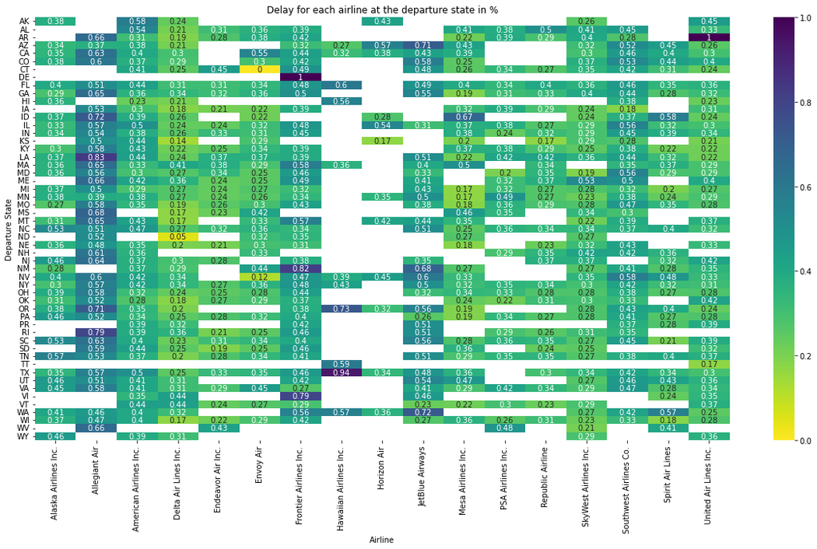

```python
#Plot the heatmap
plt.figure(figsize=(20,10))
sns.heatmap(state_carrier_delay_pivot, annot=True, cmap='viridis_r')
plt.ylabel('Departure State')
plt.xlabel('Airline')
plt.title('Delay for each airline at the departure state in %');
```

As with the cancellation heatmap, if you plot the dataframe as is, there are too many data points, rendering the plot clustered and difficult to read.

Again, let's focus on the top 5 states again.

```python
#Get a subset of  the pivot dataframe using top_5_state
delay_top5 = state_carrier_delay_pivot.loc[top_5_state]
```

```python
#Print that dataframe
delay_top5
```

| CARRIER_DESCRIPTION ORIGIN_STATE_ABR | Alaska Airlines Inc. | Allegiant Air | American Airlines Inc. | Delta Air Lines Inc. | Endeavor Air Inc. | Envoy Air | Frontier Airlines Inc. | Hawaiian Airlines Inc. | Horizon Air | JetBlue Airways | Mesa Airlines Inc. | PSA Airlines Inc. | Republic Airline | SkyWest Airlines Inc. | Southwest Airlines Co. | Spirit Air Lines | United Air Lines Inc. |
| --- | --- | --- | --- | --- | --- | --- | --- | --- | --- | --- | --- | --- | --- | --- | --- | --- | --- |
| CA | 0.35 | 0.63 | 0.40 | 0.30 | NaN | 0.55 | 0.44 | 0.32 | 0.38 | 0.43 | 0.39 | NaN | NaN | 0.30 | 0.46 | 0.40 | 0.30 |
| TX | 0.35 | 0.57 | 0.50 | 0.25 | 0.33 | 0.35 | 0.46 | 0.94 | 0.34 | 0.48 | 0.36 | NaN | 0.30 | 0.34 | 0.42 | 0.34 | 0.30 |
| FL | 0.40 | 0.51 | 0.44 | 0.31 | 0.31 | 0.34 | 0.48 | 0.60 | NaN | 0.49 | 0.40 | 0.34 | 0.40 | 0.36 | 0.46 | 0.35 | 0.36 |
| NY | 0.30 | 0.57 | 0.42 | 0.34 | 0.27 | 0.36 | 0.48 | 0.43 | NaN | 0.50 | 0.32 | 0.35 | 0.34 | 0.30 | 0.42 | 0.32 | 0.31 |
| IL | 0.33 | 0.57 | 0.50 | 0.24 | 0.24 | 0.32 | 0.48 | NaN | 0.54 | 0.31 | 0.37 | 0.38 | 0.27 | 0.29 | 0.56 | 0.32 | 0.30 |

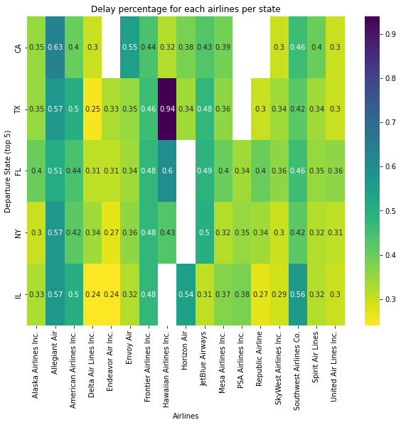

```python
#Create the heatmap
plt.figure(figsize=(10,8))
sns.heatmap(delay_top5, annot=True, cmap='viridis_r')
plt.ylabel('Departure State (top 5)')
plt.xlabel('Airlines')
plt.title('Delay percentage for each airlines per state');
```

Hawaiian Airlines appears to perform the worst in Texas. This is the only point that stands out. We do not see any other pattern indicating that an airline is performing better or worse depending on the state it's flying from.

```python
flight_copy.to_csv('flight_copy.csv', index=False)
```

### Talk about some of the relationships you observed in this part of the investigation. Were there features that strengthened each other in terms of looking at your feature(s) of interest?

We found out that afternoon and evening not only have the highest percentage of delays and cancellations, but their delays tend to be longer. Flights departing in the morning or at night tend to arrive earlier. Those trends show us that the departure time correlates to whether a flight will be canceled or delayed.

Some airlines perform better than others; however, cancellations do not correlate with delays. An airline with a high delay percentage doesn't necessarily mean that the cancellation rate is also high and vice versa.

### Were there any interesting or surprising interactions between features?

Airlines, states of origin, and delay/cancellation percentages were not correlated. During one of our bivariate analyses, we observed that certain airlines cancel their flights mainly because of the weather. Therefore, I expected them to behave differently depending on where they were departing from, but it does not appear so. This lack of correlation is less surprising when it comes to delay since the two leading causes for delays are Carrier and Late Aircraft, issues that stem from the airline side and its crew and management, unrelated to the airport or the state itself.

## Conclusions

The main goal of this exploration was to study, through univariate, bivariate, and multivariate visualization, the performance of approximately two million US domestic flights over the summer of 2022. Through this study, we mainly focused on delays and cancellations. The dataset was ready for analysis after a quick visual and programmatic assessment and a light data cleaning. We were interested in highlighting and discovering any pattern that could help identify the variables linked to the delayed or canceled flights.

We started with some univariate visualization that helped us better understand the data and identify the points of interest. We discovered that the weather was the main reason for flight cancellation, and carrier and late aircraft were the main reasons for delays.

We then focused on the bivariate analysis, where we dived deeper into the relationship between delay and cancellation and the other variables. We discovered that the East Coast is home to several states with a high cancellation percentage. Delay-wise, Delaware performs poorly, with delays of an average of 180 minutes. We expected long-haul flights to have longer delays than short-haul hauls, but the data showed us that the opposite is true. Distance is also not correlated to cancellation. Weather is confirmed as causing the longest delays, with over an hour delay on average.

Finally, we looked closely at how the variables interacted with one another through a multivariate analysis. The departure time affects delays, with evening and afternoon having more frequent and longer delays. Although we saw that some states and airlines fare better or worse than others on their own, we could not establish a correlation between delays/cancellations, states, and airlines.

Overall, this dataset was instructive and gave us some fascinating insight into which variables affect flight performance and which don't.